# group6_sprint6_dev

## Sprint 6

## Project 6: `GoodLife`

**Group 6:**  
Hamna Ashraf - 8826836  
John Alber - 8976716  
Simardeep Singh - 8976948

### **Required Libraries**

```python
import pandas as pd
import matplotlib.pyplot as plt
import seaborn as sns
from sklearn.preprocessing import LabelEncoder
import plotly.express as px
from sklearn.model_selection import train_test_split
from sklearn.linear_model import LogisticRegression
from sklearn.metrics import accuracy_score, confusion_matrix, classification_report
from sklearn.ensemble import RandomForestClassifier
from sklearn.linear_model import LinearRegression
from sklearn.metrics import mean_squared_error, r2_score
```

## **Data Loading**

```python
dfB = pd.read_csv('E:\Conestoga\Term 2\AI for business\Sprint 6\problem1.csv')
dfA = pd.read_csv('E:\Conestoga\Term 2\AI for business\Sprint 6\problem2.csv')
```

Check dataset is loaded properly

```python
dfB.head()
```

|  | number_people | date | timestamp | day_of_week | is_weekend | is_holiday | temperature | is_start_of_semester | is_during_semester | month | hour |
| --- | --- | --- | --- | --- | --- | --- | --- | --- | --- | --- | --- |
| 0 | 37 | 2015-08-14 17:00:11-07:00 | 61211 | 4 | 0 | 0 | 71.76 | 0 | 0 | 8 | 17 |
| 1 | 45 | 2015-08-14 17:20:14-07:00 | 62414 | 4 | 0 | 0 | 71.76 | 0 | 0 | 8 | 17 |
| 2 | 40 | 2015-08-14 17:30:15-07:00 | 63015 | 4 | 0 | 0 | 71.76 | 0 | 0 | 8 | 17 |
| 3 | 44 | 2015-08-14 17:40:16-07:00 | 63616 | 4 | 0 | 0 | 71.76 | 0 | 0 | 8 | 17 |
| 4 | 45 | 2015-08-14 17:50:17-07:00 | 64217 | 4 | 0 | 0 | 71.76 | 0 | 0 | 8 | 17 |

```python
dfA.head()
```

|  | booking_id | months_as_member | weight | days_before | day_of_week | time | category | attended |
| --- | --- | --- | --- | --- | --- | --- | --- | --- |
| 0 | 1 | 17 | 79.56 | 8 | Wed | PM | Strength | 0 |
| 1 | 2 | 10 | 79.01 | 2 | Mon | AM | HIIT | 0 |
| 2 | 3 | 16 | 74.53 | 14 | Sun | AM | Strength | 0 |
| 3 | 4 | 5 | 86.12 | 10 | Fri | AM | Cycling | 0 |
| 4 | 5 | 15 | 69.29 | 8 | Thu | AM | HIIT | 0 |

## **Data Cleaning and Preprocessing**

### Checking missing values

```python
print(dfB.isnull().sum())
```

```
number_people           0
date                    0
timestamp               0
day_of_week             0
is_weekend              0
is_holiday              0
temperature             0
is_start_of_semester    0
is_during_semester      0
month                   0
hour                    0
dtype: int64
```

Equipment Utilization dataset, there are no missing values

Checking if is_holiday is useful for the analysis or can be dropped.

```python
print(dfB['is_holiday'].value_counts())
```

```
is_holiday
0    62024
1      160
Name: count, dtype: int64
```

```python
holiday_data = dfB[dfB['is_holiday'] == 1]
total_people_on_holidays = holiday_data['number_people'].sum()

print(f"Total number of people in gym on holidays: {total_people_on_holidays}")
```

```
Total number of people in gym on holidays: 1203
```

According to this, though it is a small value compared to others, however it should not be ignored.

Dropping the irrelevant feature from dataset B. is_week is being dropped because we can get that data from day_of_week column and know if it's the weekend or not.

```python
dfB = dfB.drop(['timestamp', 'is_weekend'], axis=1)
```

Now checking for any null values for class utilization dataset:

```python
dfA.info()
```

```
<class 'pandas.core.frame.DataFrame'>
RangeIndex: 1500 entries, 0 to 1499
Data columns (total 8 columns):
 #   Column            Non-Null Count  Dtype
---  ------            --------------  -----
 0   booking_id        1500 non-null   int64
 1   months_as_member  1500 non-null   int64
 2   weight            1480 non-null   float64
 3   days_before       1500 non-null   object
 4   day_of_week       1500 non-null   object
 5   time              1500 non-null   object
 6   category          1500 non-null   object
 7   attended          1500 non-null   int64
dtypes: float64(1), int64(3), object(4)
memory usage: 93.9+ KB
```

```python
print(dfA.isnull().sum())
```

```
booking_id           0
months_as_member     0
weight              20
days_before          0
day_of_week          0
time                 0
category             0
attended             0
dtype: int64
```

```python
dfA = dfA.dropna(subset=['weight'])
```

```python
dfA.head()
```

|  | booking_id | months_as_member | weight | days_before | day_of_week | time | category | attended |
| --- | --- | --- | --- | --- | --- | --- | --- | --- |
| 0 | 1 | 17 | 79.56 | 8 | Wed | PM | Strength | 0 |
| 1 | 2 | 10 | 79.01 | 2 | Mon | AM | HIIT | 0 |
| 2 | 3 | 16 | 74.53 | 14 | Sun | AM | Strength | 0 |
| 3 | 4 | 5 | 86.12 | 10 | Fri | AM | Cycling | 0 |
| 4 | 5 | 15 | 69.29 | 8 | Thu | AM | HIIT | 0 |

```python
non_numerical_columns = dfA.select_dtypes(include=['object', 'category']).columns
for column in non_numerical_columns:
    if column in dfA.columns:
        unique_values = dfA[column].unique()
        print(f"Unique values in '{column}':")
        print(unique_values)
        print("\n")
    else:
        print(f"Column '{column}' not found in DataFrame.")
```

```
Unique values in 'days_before':
['8' '2' '14' '10' '6' '4' '9' '12' '5' '3' '7' '13' '12 days' '20' '1'
 '15' '6 days' '11' '13 days' '3 days' '16' '1 days' '7 days' '8 days'
 '10 days' '14 days' '17' '5 days' '2 days' '4 days' '29']


Unique values in 'day_of_week':
['Wed' 'Mon' 'Sun' 'Fri' 'Thu' 'Wednesday' 'Fri.' 'Tue' 'Sat' 'Monday']


Unique values in 'time':
['PM' 'AM']


Unique values in 'category':
['Strength' 'HIIT' 'Cycling' 'Yoga' '-' 'Aqua']
```

We found inconsistencies in the dataset, so let's fix this:

```python
dfA['days_before'] = dfA['days_before'].str.replace(' days', '').astype(int)
print(dfA['days_before'].unique())
```

```
[ 8  2 14 10  6  4  9 12  5  3  7 13 20  1 15 11 16 17 29]
```

Remove the string (days) from the values and converting them to type int.

```python
days = {
    'Mon': 'Monday',
    'Tue': 'Tuesday',
    'Wed': 'Wednesday',
    'Thu': 'Thursday',
    'Fri': 'Friday',
    'Sat': 'Saturday',
    'Sun': 'Sunday',
    'Fri.': 'Friday'
}

dfA['day_of_week'] = dfA['day_of_week'].replace(days)
```

```python
dfA['category'] = dfA['category'].replace('-', 'No Category')
```

```python
nk_count = dfA['category'].value_counts().get('No Category', 0)
print(f"Number of 'No Category' values in 'category': {nk_count}")
```

```
Number of 'No Category' values in 'category': 13
```

As there are only a few valyes with unknown category therefore, we can remove these rows.

```python
dfA = dfA[dfA['category'] != 'No Category']
```

```python
non_numerical_columns = dfA.select_dtypes(include=['object', 'category']).columns
for column in non_numerical_columns:
    if column in dfA.columns:
        unique_values = dfA[column].unique()
        print(f"Unique values in '{column}':")
        print(unique_values)
        print("\n")
    else:
        print(f"Column '{column}' not found in DataFrame.")
```

```
Unique values in 'day_of_week':
['Wednesday' 'Monday' 'Sunday' 'Friday' 'Thursday' 'Tuesday' 'Saturday']


Unique values in 'time':
['PM' 'AM']


Unique values in 'category':
['Strength' 'HIIT' 'Cycling' 'Yoga' 'Aqua']
```

```python
dfA = dfA.set_index('booking_id')
```

```python
dfA
```

| booking_id | months_as_member | weight | days_before | day_of_week | time | category | attended |
| --- | --- | --- | --- | --- | --- | --- | --- |
| 1 | 17 | 79.56 | 8 | Wednesday | PM | Strength | 0 |
| 2 | 10 | 79.01 | 2 | Monday | AM | HIIT | 0 |
| 3 | 16 | 74.53 | 14 | Sunday | AM | Strength | 0 |
| 4 | 5 | 86.12 | 10 | Friday | AM | Cycling | 0 |
| 5 | 15 | 69.29 | 8 | Thursday | AM | HIIT | 0 |
| ... | ... | ... | ... | ... | ... | ... | ... |
| 1496 | 21 | 79.51 | 10 | Friday | AM | HIIT | 0 |
| 1497 | 29 | 89.55 | 2 | Monday | AM | Strength | 0 |
| 1498 | 9 | 87.38 | 4 | Tuesday | AM | HIIT | 0 |
| 1499 | 34 | 68.64 | 14 | Sunday | AM | Aqua | 0 |
| 1500 | 20 | 94.39 | 8 | Thursday | AM | Cycling | 1 |

1467 rows × 7 columns

## **EDA**

`Problem B: Optimizing Gym Equipment Utilization`

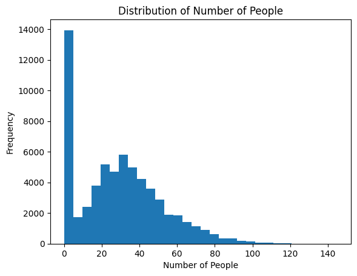

```python
# Histogram of number_people
plt.hist(dfB['number_people'], bins=30)
plt.xlabel('Number of People')
plt.ylabel('Frequency')
plt.title('Distribution of Number of People')
plt.show()
```

This histogram suggests that the gym experiences many low-attendance periods, with occasional spikes in crowding.

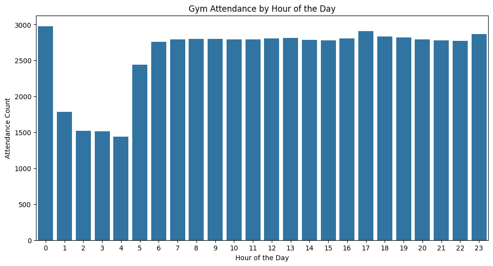

```python
plt.figure(figsize=(12, 6))
sns.countplot(x='hour', data=dfB)
plt.title('Gym Attendance by Hour of the Day')
plt.xlabel('Hour of the Day')
plt.ylabel('Attendance Count')
plt.show()
```

Let's check at which hour the number of people are 0 - 10

```python
few_people = dfB[(dfB['number_people'] >= 0) & (dfB['number_people'] <= 10)]
```

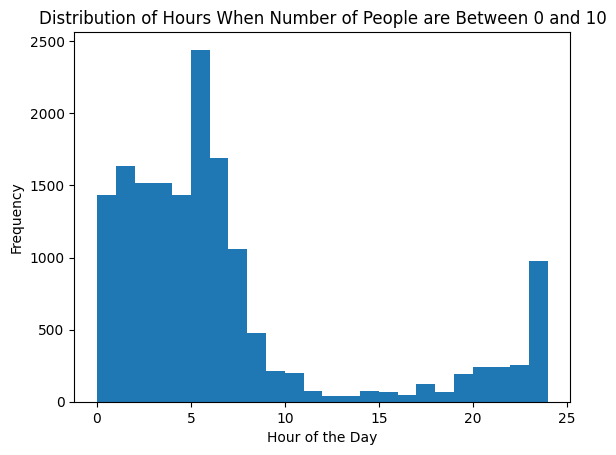

```python
# Plot histogram of the hours when number of people is between 0 and 10
plt.hist(few_people['hour'], bins=24, range=(0, 24))
plt.xlabel('Hour of the Day')
plt.ylabel('Frequency')
plt.title('Distribution of Hours When Number of People are Between 0 and 10')
plt.show()
```

It can be seen in this graph that at hours 1am - 6am, there is high confidence that the number of people in gym are in range 0 - 10

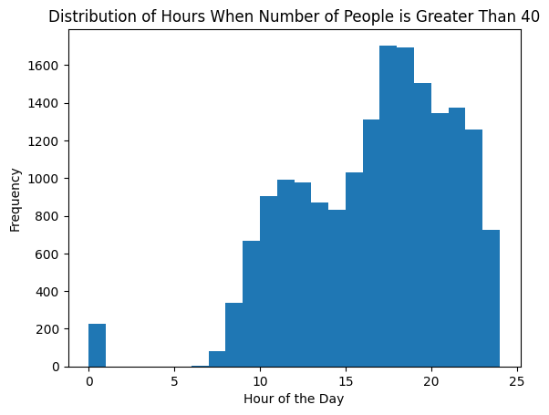

```python
df_more_people = dfB[dfB['number_people'] > 40]
plt.hist(df_more_people['hour'], bins=24, range=(0, 24))
plt.xlabel('Hour of the Day')
plt.ylabel('Frequency')
plt.title('Distribution of Hours When Number of People is Greater Than 40')
plt.show()
```

Gyms are the most busy during hours 5pm - 11pm where the number of people in gym are mostly greater than 40.

```python
people_by_day = dfB.groupby('day_of_week')['number_people'].sum().reset_index()

day_mapping = {0: 'Monday', 1: 'Tuesday', 2: 'Wednesday', 3: 'Thursday', 4: 'Friday', 5: 'Saturday', 6: 'Sunday'}
people_by_day['day_of_week'] = people_by_day['day_of_week'].map(day_mapping)

fig = px.pie(people_by_day, names='day_of_week', values='number_people', title='Distribution of People Coming to the Gym Throughout the Week')

# Show the plot
fig.show()
```

[output not shown]

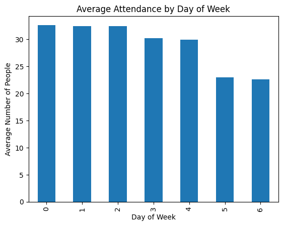

```python
weekly_attendance = dfB.groupby('day_of_week')['number_people'].mean()
weekly_attendance.plot(kind='bar')
plt.title('Average Attendance by Day of Week')
plt.ylabel('Average Number of People')
plt.xlabel('Day of Week')
plt.show()
```

This graph shows the average attendance throughout the week.

```python
# Total number of people attending during weekends (Saturday and Sunday)
people_weekend = dfB[dfB['day_of_week'].isin([5, 6])]['number_people'].sum()

# Total number of people attending during weekdays (Monday to Friday)
people_weekday = dfB[~dfB['day_of_week'].isin([5, 6])]['number_people'].sum()
total_people = dfB['number_people'].sum()

percentage_weekend = (people_weekend / total_people) * 100 if total_people > 0 else 0
percentage_weekday = (people_weekday / total_people) * 100 if total_people > 0 else 0

print(f"Percentage of people attending on weekdays: {percentage_weekday:.2f}%")
print(f"Percentage of people attending on weekends: {percentage_weekend:.2f}%")
```

```
Percentage of people attending on weekdays: 77.83%
Percentage of people attending on weekends: 22.17%
```

1. Higher Attendance on Weekdays: These percentages clearly shows that gym attendance is significantly higher on weekdays compared to weekends. This might be because people prefer to stick to their regular workout routine during the week, possibly integrating gym visits with their work schedules.
2. Lower Attendance on Weekends: Attendance drops on weekends, indicating that fewer people visit the gym during these days. This could be due to people engaging in other activities or preferring to rest over the weekend.

```python
people_by_month = dfB.groupby('month')['number_people'].sum().reset_index()

month_mapping = {1: 'January', 2: 'February', 3: 'March', 4: 'April', 5: 'May', 6: 'June',
                 7: 'July', 8: 'August', 9: 'September', 10: 'October', 11: 'November', 12: 'December'}
people_by_month['month'] = people_by_month['month'].map(month_mapping)

fig = px.bar(people_by_month, x='month', y='number_people',
             title='Total Number of People Coming to the Gym Each Month',
             labels={'number_people': 'Total Number of People', 'month': 'Month'})

# Show the plot
fig.show()
```

[output not shown]

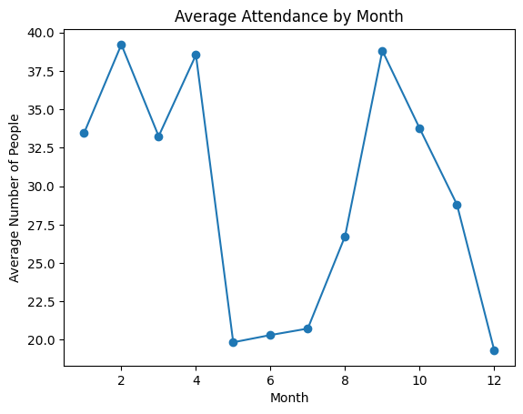

```python
monthly_attendance = dfB.groupby('month')['number_people'].mean()
monthly_attendance.plot(kind='line', marker='o')
plt.title('Average Attendance by Month')
plt.ylabel('Average Number of People')
plt.xlabel('Month')
plt.show()
```

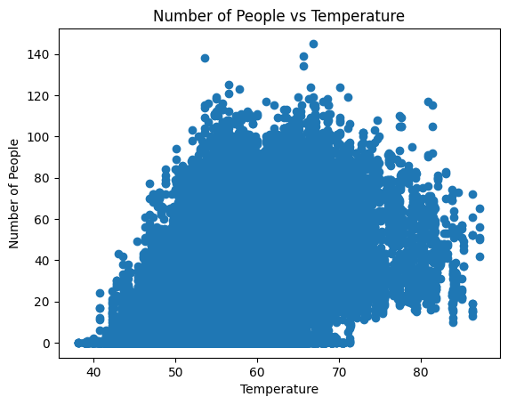

```python
# Scatter plot of number_people vs temperature
plt.scatter(dfB['temperature'], dfB['number_people'])
plt.xlabel('Temperature')
plt.ylabel('Number of People')
plt.title('Number of People vs Temperature')
plt.show()
```

```python
dfB.info()
```

```
<class 'pandas.core.frame.DataFrame'>
RangeIndex: 62184 entries, 0 to 62183
Data columns (total 9 columns):
 #   Column                Non-Null Count  Dtype
---  ------                --------------  -----
 0   number_people         62184 non-null  int64
 1   date                  62184 non-null  object
 2   day_of_week           62184 non-null  int64
 3   is_holiday            62184 non-null  int64
 4   temperature           62184 non-null  float64
 5   is_start_of_semester  62184 non-null  int64
 6   is_during_semester    62184 non-null  int64
 7   month                 62184 non-null  int64
 8   hour                  62184 non-null  int64
dtypes: float64(1), int64(7), object(1)
memory usage: 4.3+ MB
```

```python
numerical_df = dfB.select_dtypes(include=[int, float])
correlation_matrix = numerical_df.corr()

fig = px.imshow(correlation_matrix, text_auto=True, aspect="auto", color_continuous_scale='Viridis')
fig.update_layout(title='Correlation Matrix', xaxis_title='Features', yaxis_title='Features')
fig.show()
```

[output not shown]

`Problem A: Optimizing Group Fitness Class Utilization`

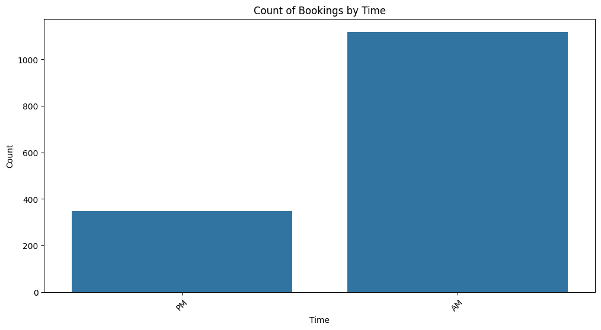

```python
plt.figure(figsize=(12, 6))
sns.countplot(x='time', data=dfA)
plt.title('Count of Bookings by Time')
plt.xlabel('Time')
plt.ylabel('Count')
plt.xticks(rotation=45)
plt.show()
```

1. Higher Bookings in the Morning (AM): The chart indicates that a significantly higher number of bookings are made for morning (AM) sessions compared to afternoon/evening (PM) sessions. This suggests that members prefer to attend the gym in the morning rather than later in the day.
2. Lower PM Bookings: The number of bookings in the PM is noticeably lower, indicating a potential underutilization of gym resources during this time.

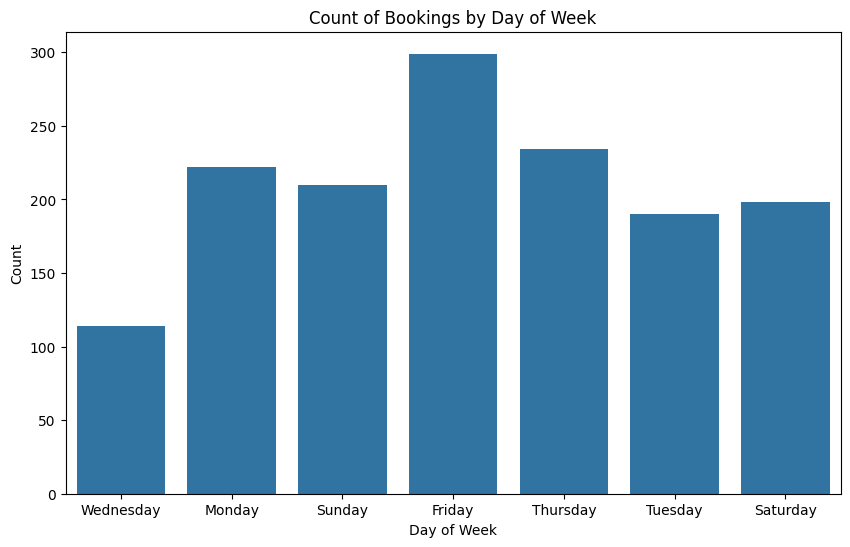

```python
plt.figure(figsize=(10, 6))
sns.countplot(x='day_of_week', data=dfA)
plt.title('Count of Bookings by Day of Week')
plt.xlabel('Day of Week')
plt.ylabel('Count')
plt.show()
```

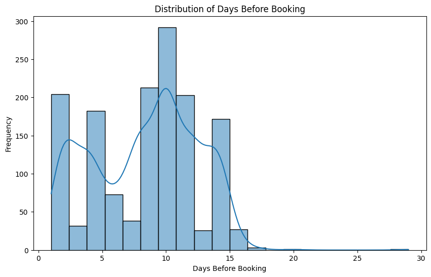

```python
plt.figure(figsize=(10, 6))
sns.histplot(dfA['days_before'], kde=True)
plt.title('Distribution of Days Before Booking')
plt.xlabel('Days Before Booking')
plt.ylabel('Frequency')
plt.show()
```

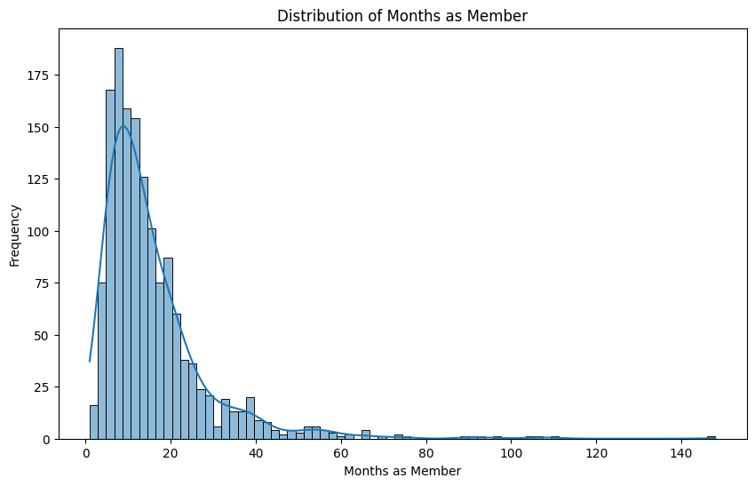

```python
plt.figure(figsize=(10, 6))
sns.histplot(dfA['months_as_member'], kde=True)
plt.title('Distribution of Months as Member')
plt.xlabel('Months as Member')
plt.ylabel('Frequency')
plt.show()
```

1. Newer Members Dominant: The histogram shows that a significant portion of the gym's members have been with the gym for a relatively short period, particularly within the first 20 months. This indicates that there is a high number of newer members.
2. Exponential Decline: There is a steep decline in the number of members as the number of months increases, suggesting that fewer members have been with the gym for a long duration. This could indicate either a high turnover rate or that newer members constitute the majority of the active membership base.
3. Long-Term Members: Although less common, there are some members who have been with the gym for several years (over 60 months), showing that a small portion of the membership is long-term.

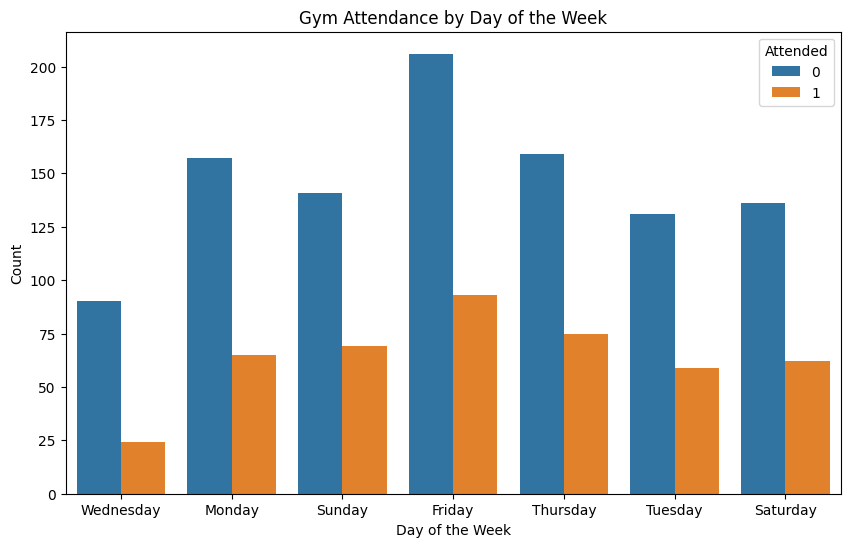

```python
plt.figure(figsize=(10, 6))
sns.countplot(x='day_of_week', hue='attended', data=dfA)
plt.title('Gym Attendance by Day of the Week')
plt.xlabel('Day of the Week')
plt.ylabel('Count')
plt.legend(title='Attended')
plt.show()
```

Higher Non-Attendance Across All Days: For every day of the week, the count of members who did not attend (0) is consistently higher than those who attended (1). This suggests that a significant proportion of bookings do not result in actual attendance.

Most Non-Attendance on Friday: Friday shows the highest count of non-attendance, indicating that many members book classes or gym slots for Friday but fail to show up.

Attendance Pattern on Weekends: While non-attendance is still higher on weekends (Saturday and Sunday), the gap between attendance and non-attendance is slightly narrower compared to weekdays. This suggests that weekend bookings may be slightly more reliable.

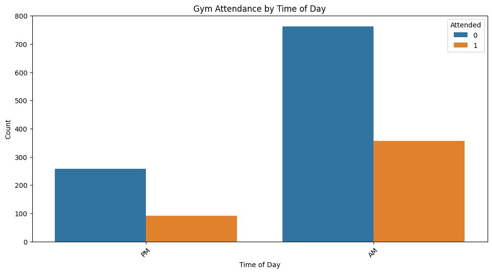

```python
plt.figure(figsize=(12, 6))
sns.countplot(x='time', hue='attended', data=dfA)
plt.title('Gym Attendance by Time of Day')
plt.xlabel('Time of Day')
plt.ylabel('Count')
plt.xticks(rotation=45)
plt.legend(title='Attended')
plt.show()
```

Higher Non-Attendance in the Morning (AM): The count of non-attendance (0) is significantly higher in the morning (AM) compared to the afternoon/evening (PM). This suggests that while many members book sessions for the morning, a large portion of them do not attend.

Overall AM Popularity: Despite the higher non-attendance, the total number of bookings in the morning is still significantly higher than in the PM, showing that morning sessions are more popular overall.

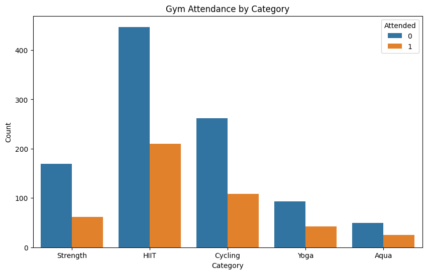

```python
plt.figure(figsize=(10, 6))
sns.countplot(x='category', hue='attended', data=dfA)
plt.title('Gym Attendance by Category')
plt.xlabel('Category')
plt.ylabel('Count')
plt.legend(title='Attended')
plt.show()
```

```python
le = LabelEncoder()
dfA['time'] = le.fit_transform(dfA['time'])
dfA = pd.get_dummies(dfA, columns=['day_of_week', 'category'], drop_first=True)
```

High Non-Attendance in HIIT Classes: HIIT (High-Intensity Interval Training) has the highest count of non-attendance (0) among all categories. Despite being popular for bookings, a significant number of members fail to attend these sessions.

Cycling and Strength: Both Cycling and Strength categories show a similar pattern, with more non-attendance than attendance. However, these categories still attract a relatively high number of attendees compared to others.

Lower Attendance in Yoga and Aqua: Yoga and Aqua categories have fewer overall bookings and attendance compared to categories like HIIT and Cycling. The non-attendance rate is lower but still significant relative to the number of bookings.

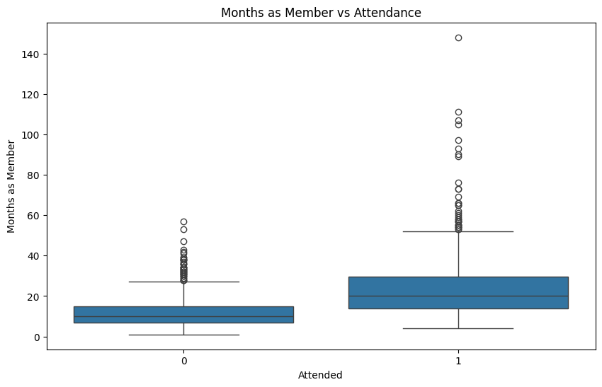

```python
# Box plot of months as member vs attendance
plt.figure(figsize=(10, 6))
sns.boxplot(x='attended', y='months_as_member', data=dfA)
plt.title('Months as Member vs Attendance')
plt.xlabel('Attended')
plt.ylabel('Months as Member')
plt.show()
```

Longer Memberships Correlate with Attendance: The plot shows that members who attended (1) tend to have been with the gym for a longer period on average compared to those who did not attend (0). The median months as a member for those who attended is higher, indicating that longer-tenured members are more likely to show up for their bookings.

Higher Variability Among Attendees: There is greater variability in the number of months as a member among those who attended, with some members having been with the gym for over 60 months (5 years) or more. This suggests that committed, long-term members are generally more reliable in attending their booked sessions.

Outliers in Attendance: There are several outliers on both sides of the box plot, especially in the attendance (1) category, indicating that a few long-term members have been with the gym for an exceptionally long time (over 100 months).

Non-Attendees Tend to be Newer Members: Members who did not attend (0) tend to have shorter membership durations, with the majority being members for less than 20 months. This could suggest that newer members are less consistent in attending their booked sessions.

```python
correlation_matrix_A = dfA.corr()

fig = px.imshow(correlation_matrix_A, text_auto=True, aspect="auto", color_continuous_scale='Viridis')
fig.update_layout(title='Correlation Matrix', xaxis_title='Features', yaxis_title='Features')
fig.show()
```

[output not shown]

### Model training:

#### Prediction for Problem A: (Attended/Not attended)

```python
X = dfA.drop(columns=['attended'])  # Drop the label
y = dfA['attended']

# Split the data into training and testing sets
X_train, X_test, y_train, y_test = train_test_split(X, y, test_size=0.2, random_state=42)
```

```python
log_reg = LogisticRegression(random_state=42, max_iter=1000)
log_reg.fit(X_train, y_train)

# Predict on the test set
y_pred_log_reg = log_reg.predict(X_test)

# Evaluate the model
accuracy_log_reg = accuracy_score(y_test, y_pred_log_reg)
conf_matrix_log_reg = confusion_matrix(y_test, y_pred_log_reg)
class_report_log_reg = classification_report(y_test, y_pred_log_reg)

print(f"Logistic Regression Accuracy: {accuracy_log_reg:.2f}")
print("Confusion Matrix:")
print(conf_matrix_log_reg)
print("Classification Report:")
print(class_report_log_reg)
```

```
Logistic Regression Accuracy: 0.76
Confusion Matrix:
[[190  21]
 [ 49  34]]
Classification Report:
              precision    recall  f1-score   support

           0       0.79      0.90      0.84       211
           1       0.62      0.41      0.49        83

    accuracy                           0.76       294
   macro avg       0.71      0.66      0.67       294
weighted avg       0.75      0.76      0.75       294
```

```python
rf = RandomForestClassifier(random_state=42, n_estimators=100)
rf.fit(X_train, y_train)

# Predict on the test set
y_pred_rf = rf.predict(X_test)

# Evaluate the model
accuracy_rf = accuracy_score(y_test, y_pred_rf)
conf_matrix_rf = confusion_matrix(y_test, y_pred_rf)
class_report_rf = classification_report(y_test, y_pred_rf)

print(f"Random Forest Accuracy: {accuracy_rf:.2f}")
print("Confusion Matrix:")
print(conf_matrix_rf)
print("Classification Report:")
print(class_report_rf)
```

```
Random Forest Accuracy: 0.74
Confusion Matrix:
[[178  33]
 [ 44  39]]
Classification Report:
              precision    recall  f1-score   support

           0       0.80      0.84      0.82       211
           1       0.54      0.47      0.50        83

    accuracy                           0.74       294
   macro avg       0.67      0.66      0.66       294
weighted avg       0.73      0.74      0.73       294
```

- Logistic Regression has slightly better accuracy and a higher weighted average F1-score, making it generally better at correctly predicting both classes, particularly the majority class (Not Attended).
- Random Forest has better recall for the minority class (Attended), which might be more important if the goal is to maximize the identification of attendees.

#### Prediction for problem B (number of people)

```python
dfB = dfB.drop(columns=['date'])
```

```python
Xb = dfB.drop(columns=['number_people'])  # Drop the label (number of people)
yb = dfB['number_people']

# Split the data into training and testing sets
X_train, X_test, y_train, y_test = train_test_split(Xb, yb, test_size=0.2, random_state=42)
```

```python
lin_reg = LinearRegression()
lin_reg.fit(X_train, y_train)

# Predict on the test set
y_pred_lin_reg = lin_reg.predict(X_test)

# Evaluate the model
mse_lin_reg = mean_squared_error(y_test, y_pred_lin_reg)
r2_lin_reg = r2_score(y_test, y_pred_lin_reg)

print(f"Linear Regression MSE: {mse_lin_reg:.2f}")
print(f"Linear Regression R^2: {r2_lin_reg:.2f}")
```

```
Linear Regression MSE: 252.49
Linear Regression R^2: 0.51
```

```python
import xgboost as xgb
from sklearn.metrics import mean_squared_error, r2_score

# Initialize and train the XGBoost model
xgb_reg = xgb.XGBRegressor(objective='reg:squarederror', random_state=42, n_estimators=100)
xgb_reg.fit(X_train, y_train)

# Predict on the test set
y_pred_xgb = xgb_reg.predict(X_test)

# Evaluate the model
mse_xgb = mean_squared_error(y_test, y_pred_xgb)
r2_xgb = r2_score(y_test, y_pred_xgb)

print(f"XGBoost Regression MSE: {mse_xgb:.2f}")
print(f"XGBoost Regression R^2: {r2_xgb:.2f}")
```

```
XGBoost Regression MSE: 82.71
XGBoost Regression R^2: 0.84
```

```python
from sklearn.neighbors import KNeighborsRegressor
from sklearn.metrics import mean_squared_error, r2_score
from sklearn.preprocessing import StandardScaler

# Scale the features
scaler = StandardScaler()
X_train_scaled = scaler.fit_transform(X_train)
X_test_scaled = scaler.transform(X_test)

# Initialize and train the K-Nearest Neighbors Regressor
knn_reg = KNeighborsRegressor(n_neighbors=5)
knn_reg.fit(X_train_scaled, y_train)

# Predict on the test set
y_pred_knn = knn_reg.predict(X_test_scaled)

# Evaluate the model
mse_knn = mean_squared_error(y_test, y_pred_knn)
r2_knn = r2_score(y_test, y_pred_knn)

print(f"KNN Regression MSE: {mse_knn:.2f}")
print(f"KNN Regression R^2: {r2_knn:.2f}")
```

```
KNN Regression MSE: 57.77
KNN Regression R^2: 0.89
```

- *KNN Regression* is the best-performing model for Problem B, as it has the lowest MSE (57.77) and the highest R² (0.89). This means it makes the most accurate predictions about how crowded the gym will be based on the given features.
- *XGBoost Regression* is also a strong performer, with a good balance between complexity and accuracy, but it is slightly outperformed by KNN in this scenario.
- *Linear Regression* is the least suitable model for this problem, as it does not capture the relationships in the data as well as the other models.

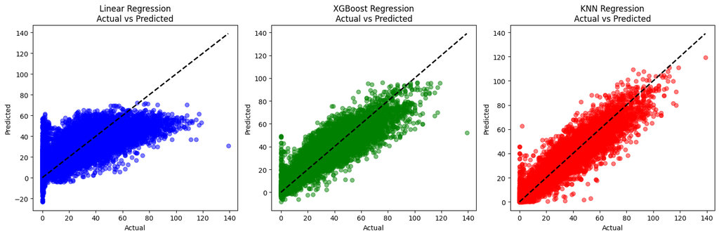

```python
# Plot for Linear Regression
plt.figure(figsize=(15, 5))

plt.subplot(1, 3, 1)
plt.scatter(y_test, y_pred_lin_reg, color='blue', alpha=0.5)
plt.plot([y_test.min(), y_test.max()], [y_test.min(), y_test.max()], 'k--', lw=2)
plt.xlabel('Actual')
plt.ylabel('Predicted')
plt.title('Linear Regression\nActual vs Predicted')

# Plot for XGBoost Regression
plt.subplot(1, 3, 2)
plt.scatter(y_test, y_pred_xgb, color='green', alpha=0.5)
plt.plot([y_test.min(), y_test.max()], [y_test.min(), y_test.max()], 'k--', lw=2)
plt.xlabel('Actual')
plt.ylabel('Predicted')
plt.title('XGBoost Regression\nActual vs Predicted')

# Plot for KNN Regression
plt.subplot(1, 3, 3)
plt.scatter(y_test, y_pred_knn, color='red', alpha=0.5)
plt.plot([y_test.min(), y_test.max()], [y_test.min(), y_test.max()], 'k--', lw=2)
plt.xlabel('Actual')
plt.ylabel('Predicted')
plt.title('KNN Regression\nActual vs Predicted')

plt.tight_layout()
plt.show()
```

In these plots we can visually see that KNN regression performed the best in predicting the relationship in the data.